# PSY 710: Assignment 1

Tinashe M. Tapera

23 January 2017

This assignment follows question 11.10 in **Fundamental Statistics for the Behavioral Sciences** by Howell.

```r
summary(hw1)
```

```
       ID            Group           Gender         YearColl
 Min.   :  2.0   Min.   :1.000   Min.   :1.000   Min.   :1.000
 1st Qu.:153.0   1st Qu.:1.000   1st Qu.:1.000   1st Qu.:2.000
 Median :349.0   Median :2.000   Median :2.000   Median :3.000
 Mean   :337.4   Mean   :1.787   Mean   :1.625   Mean   :2.685
 3rd Qu.:523.0   3rd Qu.:2.000   3rd Qu.:2.000   3rd Qu.:4.000
 Max.   :700.0   Max.   :3.000   Max.   :2.000   Max.   :4.000
                                                 NA's   :83
    College           GPA           LostPGen        AgeAtLos
 Min.   :1.000   Min.   :0.000   Min.   :1.000   Min.   : 1.00
 1st Qu.:1.000   1st Qu.:3.000   1st Qu.:1.000   1st Qu.: 9.00
 Median :1.000   Median :3.000   Median :2.000   Median :13.00
 Mean   :2.217   Mean   :2.892   Mean   :1.679   Mean   :11.91
 3rd Qu.:4.000   3rd Qu.:3.000   3rd Qu.:2.000   3rd Qu.:15.00
 Max.   :5.000   Max.   :4.000   Max.   :2.000   Max.   :20.00
 NA's   :81      NA's   :12      NA's   :241     NA's   :241
      SomT          ObsessT         SensitT         DepressT
 Min.   :41.00   Min.   :38.00   Min.   :41.00   Min.   :42.00
 1st Qu.:49.00   1st Qu.:55.00   1st Qu.:54.00   1st Qu.:54.00
 Median :53.00   Median :63.00   Median :63.00   Median :60.00
 Mean   :54.62   Mean   :61.17   Mean   :60.65   Mean   :60.94
 3rd Qu.:61.00   3rd Qu.:68.00   3rd Qu.:68.00   3rd Qu.:68.00
 Max.   :80.00   Max.   :80.00   Max.   :80.00   Max.   :80.00
 NA's   :6       NA's   :6       NA's   :6       NA's   :6
      AnxT           HostT           PhobT           ParT
 Min.   :38.00   Min.   :39.00   Min.   :45.0   Min.   :42.00
 1st Qu.:55.00   1st Qu.:51.00   1st Qu.:45.0   1st Qu.:52.00
 Median :60.00   Median :59.00   Median :56.0   Median :61.00
 Mean   :60.15   Mean   :59.43   Mean   :54.9   Mean   :59.22
 3rd Qu.:68.00   3rd Qu.:66.00   3rd Qu.:63.0   3rd Qu.:65.00
 Max.   :80.00   Max.   :80.00   Max.   :80.0   Max.   :80.00
 NA's   :6       NA's   :6       NA's   :6      NA's   :6
      PsyT           GSIT          PVTotal           PVLoss
 Min.   :46.0   Min.   :34.00   Min.   : 32.00   Min.   : 6.00
 1st Qu.:58.0   1st Qu.:56.00   1st Qu.: 68.00   1st Qu.:15.00
 Median :64.0   Median :61.00   Median : 81.00   Median :18.00
 Mean   :62.7   Mean   :62.05   Mean   : 84.08   Mean   :19.25
 3rd Qu.:70.0   3rd Qu.:68.00   3rd Qu.:100.00   3rd Qu.:24.00
 Max.   :80.0   Max.   :80.00   Max.   :148.00   Max.   :42.00
 NA's   :6      NA's   :6
    SuppTotl
 Min.   : 12.00
 1st Qu.: 60.00
 Median : 68.00
 Mean   : 66.94
 3rd Qu.: 75.00
 Max.   :108.00
```

> Use stem-and-leaf-plots and boxplots to examine the variables DepressT and SuppTotl. Summarize your findings.

First of all, the 999 is probably an error code for missing data. We’ll recode the whole data set to reflect this.

```r
recode999 = function(x){
  for(i in length(x)){
    if(x == 999){
      x = NA
    }
  }
}
hw1 = data.frame(apply(hw1, 2, function(x) replace(x, x == 999, NA)))
```

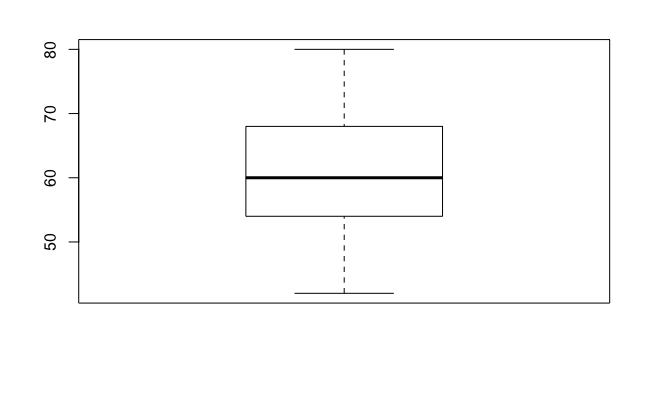

```r
boxplot(hw1$DepressT)
```

```r
stem(hw1$DepressT)
```

```
  The decimal point is at the |

  42 | 000000000000000000
  44 | 0000000000000000
  46 |
  48 | 00000000000000000000
  50 | 0
  52 | 0000000000000
  54 | 0000000000000000000000000000000000
  56 | 0000000000000000000000000000000000000000
  58 |
  60 | 000000000000000000000000000000000000000000000000000000000000
  62 | 00000000000000000000000000000000
  64 | 00000000000000000000000000
  66 | 00000
  68 | 00000000000000000000000000
  70 | 0000000000000000000000000000000000000000000000000
  72 | 00000
  74 | 0000
  76 | 000000
  78 | 000
  80 | 00000000000000000
```

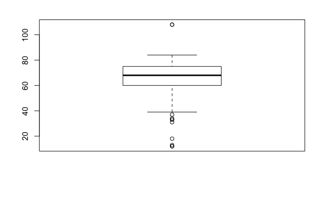

```r
boxplot(hw1$SuppTotl)
```

```r
stem(hw1$SuppTotl)
```

```
  The decimal point is 1 digit(s) to the right of the |

   1 | 223
   1 | 8
   2 |
   2 |
   3 | 1334
   3 | 79
   4 | 00124
   4 | 556677799
   5 | 00011222222333344444444
   5 | 55556666666667777777778888888888999999999999
   6 | 000000000000011111111111222222222233333333333344444444444
   6 | 5555555555566666666666666667777777777888888888888899999999999999
   7 | 000000000011111111222222222222333333333333333334444444444444444
   7 | 55555555555566666666667777777788889999999999999
   8 | 000000000000001111111111222222222223333333444444444444444
   8 |
   9 |
   9 |
  10 |
  10 | 88
```

The distribution of the variables from the stem plots seems somewhat normal, with many counts in the middle of the range, and fewer counts towards the tail ends. SuppTotl probably has a heavy left tail due to the small amount of data to the right of the distribution between the 8- and the 10-th bins. There are no statistical outliers in the DepressT variable, but many on the lower end of the distribution in the SuppTotl variable, and one on the upper end.

> Produce a scatterplot of DepressT and SuppTotl and describe your observations

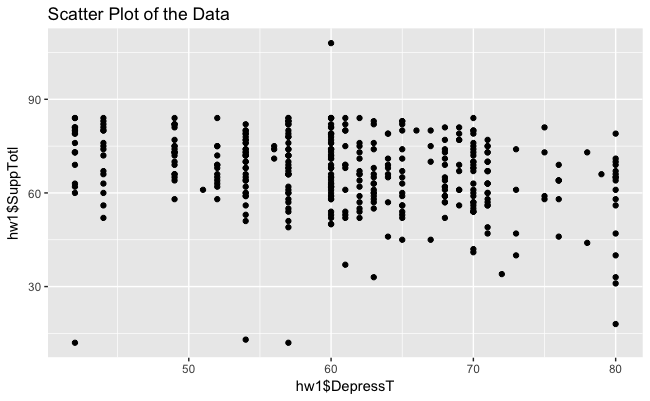

This plot doesn’t say too much, but suggests possibly a slightly negative correlation. We have to keep in mind the outliers mentioned earlier in the SuppTotl variable, so let us mark those outliers in the plot to see if there’s possibly a stronger correlation if the outliers were removed.

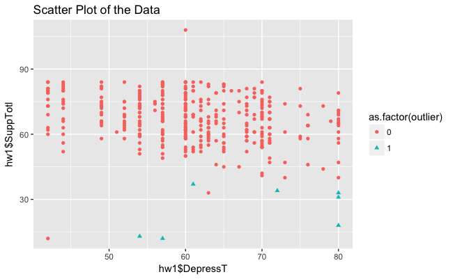

```r
outs = boxplot.stats(hw1$SuppTotl)$out
outlier = rep(0, length(hw1$SuppTotl))
outlier[match(outs, hw1$SuppTotl)] = 1
qplot(hw1$DepressT,hw1$SuppTotl, main = "Scatter Plot of the Data", shape = as.factor(outlier), col = as.factor(outlier))
```

This plot probably raises more questions than it answers to be honest, because it suggests that the points contributing to the negativity of the correlation might be invalid.

> Run a correlation analysis for the two variables. Is the correlation coefficient significant?

```r
cor.test(hw1$DepressT,hw1$SuppTotl)
```

```
    Pearson's product-moment correlation

data:  hw1$DepressT and hw1$SuppTotl
t = -5.382, df = 373, p-value = 1.305e-07
alternative hypothesis: true correlation is not equal to 0
95 percent confidence interval:
 -0.3599282 -0.1718425
sample estimates:
       cor
-0.2684419
```

It looks like the correlation coefficient is significant, as *p* is far less than 0.05. The correlation coefficient itself is -0.26, weakly negative as previously assumed.

> BUild a simple linear regression model with SuppTotl to predict DepressT. State your estimated regression equation and interpret the estimated coefficients.

The regression model would take the form $Y_i = \beta_0 + \beta_1X_i + \epsilon_i$, where Y = DepressT, X = SuppTotl, $\beta_0$ is the intercept of the model, $\beta_1$ is the coefficient of SuppTotl, and $\epsilon_i$ represents the variance of the irreducible error. Essentially:

$$DepressT = \beta_0 + \beta_1\times SuppTotl + \epsilon$$

```r
model1 = lm(DepressT ~ SuppTotl,data = hw1)
summary(model1)
```

```
Call:
lm(formula = DepressT ~ SuppTotl, data = hw1)

Residuals:
     Min       1Q   Median       3Q      Max
-30.4579  -5.8322   0.2976   6.8224  21.6067

Coefficients:
            Estimate Std. Error t value Pr(>|t|)
(Intercept)  74.9770     2.6510  28.283  < 2e-16 ***
SuppTotl     -0.2099     0.0390  -5.382  1.3e-07 ***
---
Signif. codes:  0 '***' 0.001 '**' 0.01 '*' 0.05 '.' 0.1 ' ' 1

Residual standard error: 9.168 on 373 degrees of freedom
  (6 observations deleted due to missingness)
Multiple R-squared:  0.07206,   Adjusted R-squared:  0.06957
F-statistic: 28.97 on 1 and 373 DF,  p-value: 1.305e-07
```

The intercept $\beta_0$ is estimated to be 74.977; this implies that even if levels of total support (SuppTotl) are zero, depression (DepressT) has a value of approximately 75 on their scale. This would make sense, as lack of social support wouldn’t necessarily *decrease* depression. Likewise, the coefficient for social support $\beta_1$ is -0.2099; this implies that for every unit increase in social support, depression decreases by 0.2099 units. This is also sensible, as social support is *probably likely* to decrease depression. Additionally, each of these $\beta$ estimates is significant.

> List the 4 assumptions required for a linear regression model.
- Observations are independent
- Relationship is linear
- Standard deviations of y is the same for all x
- Y varies normally around its mean

> Examine the assumptions for the fitted model.
1. The observations should be independent, as there is no inclination that any of the observations were taken from the same participant or otherwise.
2. From the scatterplot, we can assume that the relationship would be best modeled as a linear one. A non-linear relationship would probably add more complexity that it would benefit the prediction.